# Titanic Visualization

Xiaowei Hu

2024-03-11

## Introduction

The Titanic dataset serves as a captivating backdrop for our exploration, not only for its rich features but also for the poignant narrative it carries. The tragic sinking of the Titanic on its maiden voyage is a story that resonates with many, intertwined with tales of love, loss, and survival. It presents a unique opportunity to analyze how factors such as socio-economic status, family size, and other variables influenced the chances of survival during this historic event.

As we embark on this journey of data visualization, we will unravel intriguing insights such as the dynamics between wealth and survival, the impact of family size on survival rates, and other compelling patterns that emerge from the dataset. Join me as we navigate through this script and uncover the hidden stories within the Titanic dataset. Let’s begin our exploration!

```r
titanic <- titanic_train %>%
  select(Survived, Pclass, Sex, Age, SibSp, Parch, Fare) %>%
  mutate(Survived = factor(Survived),
         Pclass = factor(Pclass),
         Sex = factor(Sex))
```

## QQ-plot of Passenger Age Distribution

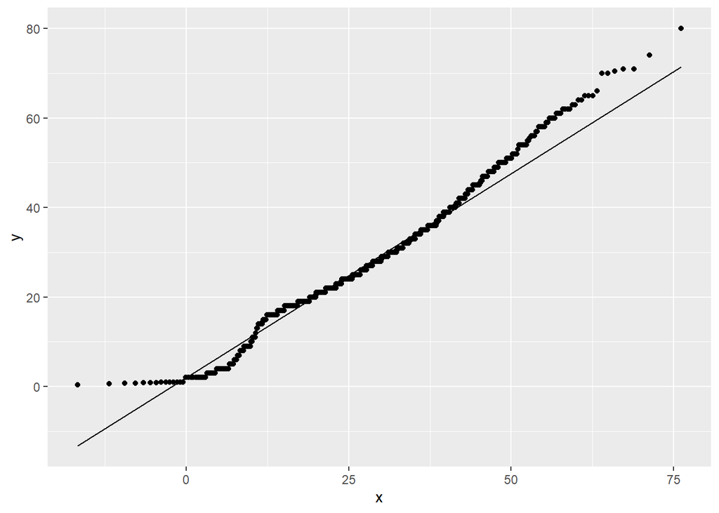

```r
params <- titanic %>%
  filter(!is.na(Age)) %>%
  summarize(mean = mean(Age), sd = sd(Age))

titanic |> filter(!is.na(Age)) |>
  ggplot(aes(sample = Age)) +
  geom_qq(dparams = params) +
  geom_qq_line(dparams = params)
```

## The Survival by Sex

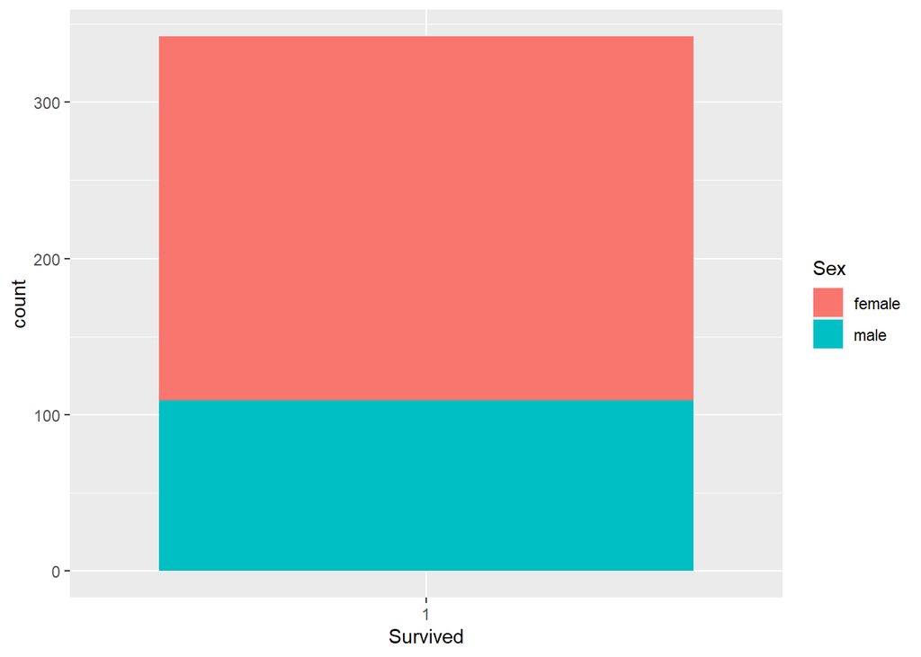

```r
titanic |> filter(Survived == 1) |>
  ggplot(aes(Survived, fill = Sex)) + geom_bar()
```

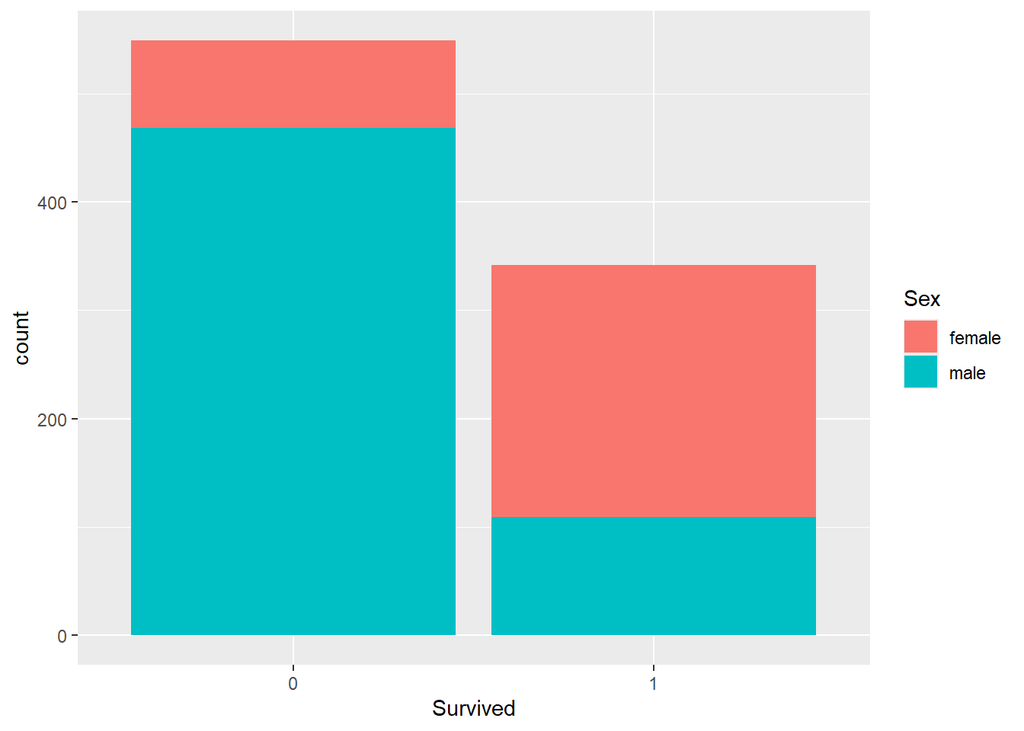

```r
titanic |> group_by(Sex) |>
  ggplot(aes(Survived, fill = Sex)) + geom_bar()
```

## Which age group is the only group more likely to survive than die?

### Which age group had the most deaths?

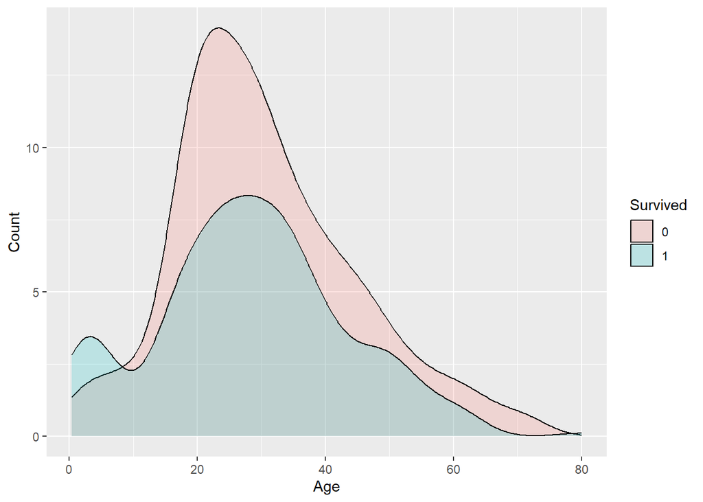

```r
titanic |> filter(!is.na(Age) & !is.na(Survived)) |>
  ggplot(aes(x=Age, y=after_stat(count), fill= Survived)) +
  geom_density(alpha = 0.2) +
  labs(y="Count")
```

### Which age group had the highest proportion of deaths?

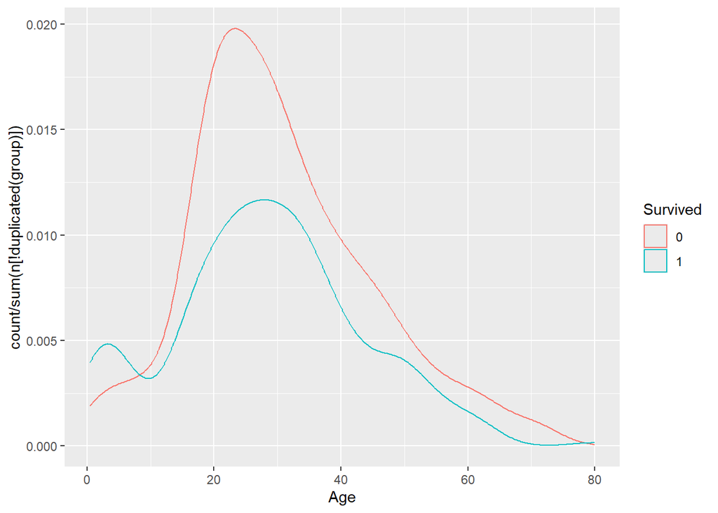

```r
titanic |> filter(!is.na(Age) & !is.na(Survived)) |>
  ggplot(aes(x=Age, y=after_stat(count / sum(n[!duplicated(group)])), color= Survived)) +
  geom_density(alpha = 0.2)
```

## Survival by Fare

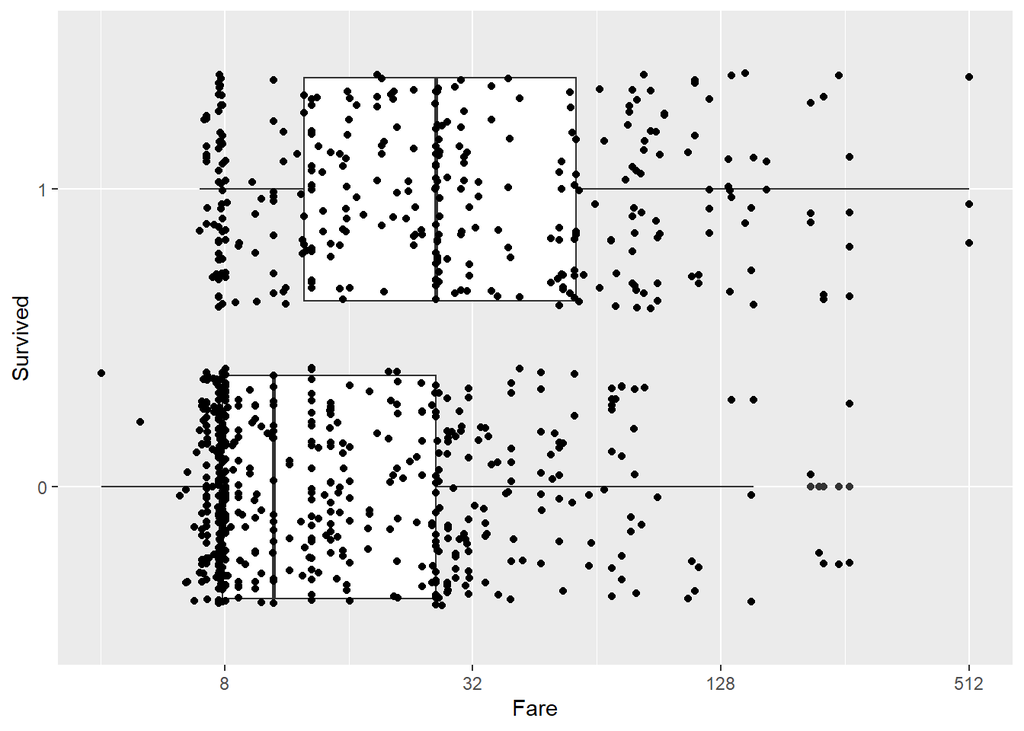

```r
titanic %>% filter(Fare != 0) %>%
  ggplot(aes(Fare, Survived)) +
  geom_boxplot() +
  geom_jitter() +
  scale_x_continuous(trans = "log2")
```

## Survival by Passenger Class

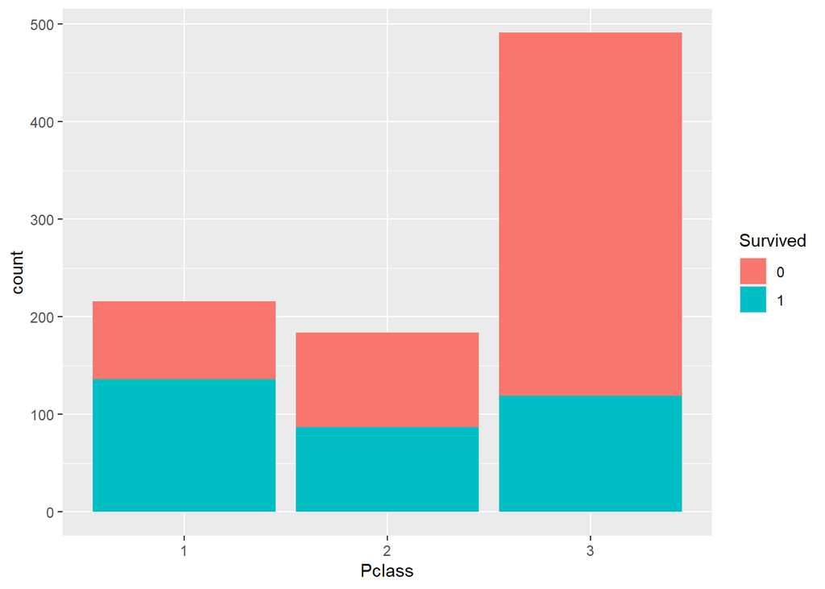

```r
titanic %>% ggplot(aes(x=Pclass, y=after_stat(count), fill= Survived)) +
  geom_bar()
```

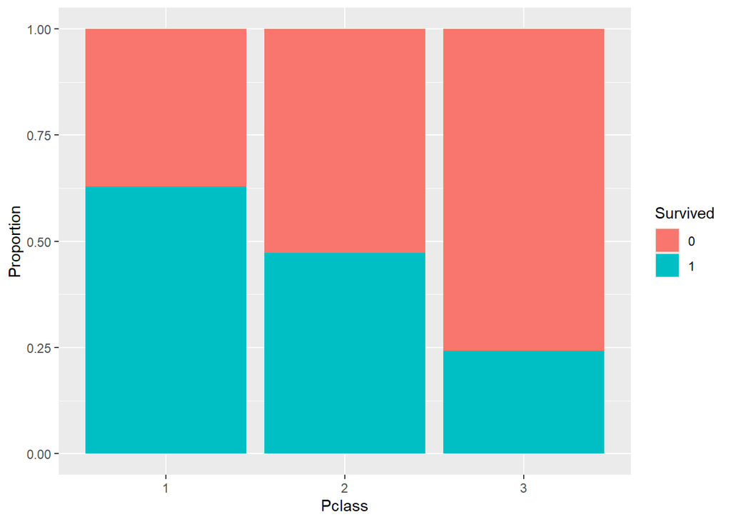

```r
titanic %>% ggplot(aes(x=Pclass, y=after_stat(count), fill= Survived)) +
  geom_bar(position = "fill") +
  labs(y="Proportion")
```

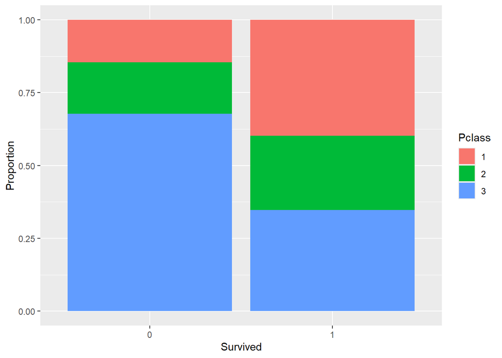

```r
titanic %>% ggplot(aes(x=Survived, y=after_stat(count), fill= Pclass)) +
  geom_bar(position = "fill") +
  labs(y="Proportion")
```

## Survival by Age, Sex and Passenger Class

### Create a grid of density plots for age, filled by survival status, with count on the y-axis, faceted by sex and passenger class.

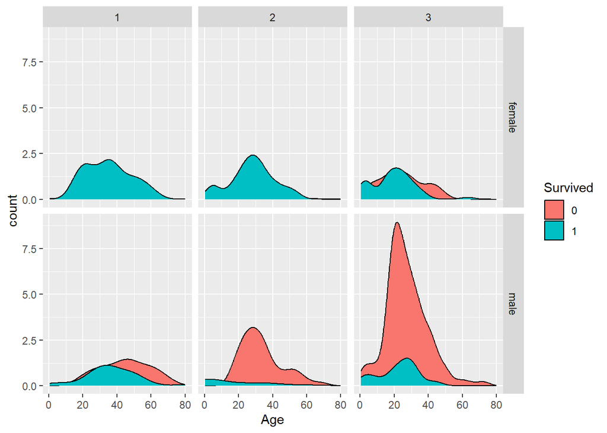

```r
titanic %>%
  ggplot(aes(x=Age, y=after_stat(count), fill=Survived)) +
  geom_density() +
  facet_grid(Sex ~ Pclass)
```